# PS08 pre-lecture: bootstrapping and confidence intervals

## Bootstrapping & confidence intervals

the **infer** workflow, one verb at a time

resampling with replacement `CI`

- `specify()`
- `generate()`
- `calculate()`
- `get_confidence_interval()`

The mean weight of a bag of chocolate-covered almonds

## The idea

Resample Your Sample

- Treat your sample as a stand-in for the population.
- Draw from it **with replacement**, same size, over and over.
- Each resample gives another value of the statistic.
- Their spread estimates the **standard error** you could not otherwise see.

## specify()

Name Your Variable

Give it a response variable, or a formula y ~ x for two variables.

## specify()

Example

the data frame

```r
almonds_sample_100 |>
  specify(response = weight)
```

the verb (function) which variable you are studying

## generate()

Resample A Thousand Times

## generate()

Example

the data frame

```r
almonds_sample_100 |>
  specify(response = weight) |>
  generate(reps = 1000, type = "bootstrap")
```

the verb (function) how many resamples resample with replacement

## calculate()

One Number Per Resample

The result has one row per replicate, and that is the bootstrap distribution.

## calculate()

the bootstrap distribution, saved for later

```r
bootstrap_means <- almonds_sample_100 |>
  specify(response = weight) |>
  generate(reps = 1000, type = "bootstrap") |>
  calculate(stat = "mean")
```

the verb (function) which statistic, for each resample

## get_confidence_interval()

Example

the bootstrap distribution

```r
percentile_ci <- bootstrap_means |>
  get_confidence_interval(level = 0.95, type = "percentile")
```

the verb (function) how confident cut at the 2.5th and 97.5th percentiles

## visualize()

Example

the bootstrap distribution

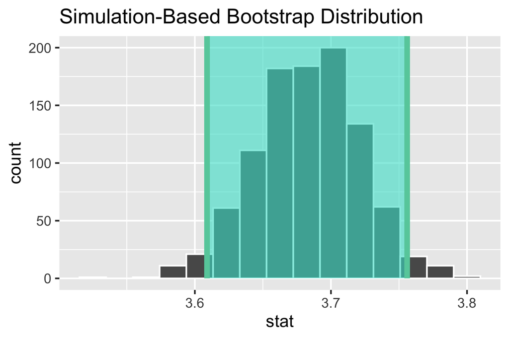

```r
visualize(bootstrap_means) +
  shade_confidence_interval(endpoints = percentile_ci)
```

shade the interval the two endpoints you just computed

## What it means

Interpreting A 95% CI

- Say: we are 95% **confident** the population mean lies in this interval.
- The confidence is in the **procedure**, not in this one interval.
- Repeat the study many times and about 95% of the intervals would cover it.
- Do **not** say there is a 95% chance the parameter is in this interval.